# HIPC ImmuneSignatures Project Meta Analysis Using Data from ImmuneSpace

2017-05-04

## PACKAGE INFORMATION

#### Created: January 2017

#### Study Authors: HIPC ImmuneSignature Collaborators

#### Package Developer: Evan Henrich (Gottardo Lab - FHCRC)

#### Contact: ehenrich@fredhutch.org

## GENERAL NOTES:

This markdown file outputs the results of the HIPC ImmuneSignatures Project using the original parameters and streamlined code from the published manuscript but run with data coming directly from ImmuneSpace. In order to save time, the gene expression matrices are pre-loaded as data within the package. The code to generate these expression matrices from ImmuneSpace / GEO can be found in the “get_GE.R” script within the package. There are two cases where data from ImmuneSpace could not be used: SDY80 (hai) and SDY400 (ge).

The SDY80 hai data available on ImmuneSpace is not incorporated into the analysis because it does not include subjects without gene expression data. Although subjects without GE data are filtered out later, they must be included in the adjust_hai.R script in order to achieve the same results for the “endPoint” variable (“fc_res_maxd30”). The original raw HAI data came from Yuri Kotliarov at NIH and is included within the package.

The SDY400 gene expression data used in the package comes from the authors at Yale University because the “series.txt” file on GEO has different probe-to-gene symbol mapping that cannot be retroactively changed, while the “non-normalized.txt” version on GEO has experiment specific subject ID mappings that were not able to be correctly given ImmuneSpace subject ids at the time of this report’s development.

Finally, the results for the “old” cohort using SDY67 data are slightly different (<0.5% Relative Error). This is believed to be due to updates or changes in the normalization package used in the meta-analysis (DESeq) between the time of the original code development and this report’s development.

#### Generating and Pre-Processing expressionSet Objects

This first code chunk shows how the expressionSet objects are constructed from ImmuneSpace data and put into a list for use in the analysis pipeline.

```r
studies <- c("SDY212", "SDY63", "SDY404", "SDY400", "SDY67",
    "SDY80")
eset_list <- list()

for (sdy in studies) {
    if (sdy == "SDY400") {
        # SDY400: Using original table because GEO series matrix produces different results in terms of gene symbols incorporated into qusage analysis, perhaps due to different normalization method(?), and GEO non-normalized.txt does not have sample names that can be mapped with available information.  All original tables come from HIPC Google Drive.
        em <- get(paste0(tolower(sdy), "_exprMxOrig"))
    } else {
        # See comments in get_GE.R for methodology of generating expression matrices. These matrices are created using online, public sources (e.g. GEO or ImmuneSpace).
        em <- getGE(sdy)
    }

    # Remove dup biosamples based on Yale HIPCMetaModuleAnalysis code comments
    if (sdy == "SDY212") {
        em <- em[, -(grep("SUB134307.*", colnames(em)))]
    }

    # No longer needed: Yale has updated the GE data in GEO to reflect these changes that were noted by F. Vallania in the origCode/hipc_multiCohortAnalysis_script_paper.R
    if (sdy == "SDY404") {
        em <- swapCols(em, "SUB120473_d0", "SUB120474_d0")  # Incorrect Sex
        em <- swapCols(em, "SUB120460_d0", "SUB120485_d28")  # Strong evidence
    }

    new_fData <- data.frame(gene_symbol = em$geneSymbol, stringsAsFactors = F)
    rownames(new_fData) <- rownames(em)
    eset <- ExpressionSet(assayData = as.matrix(em), featureData = AnnotatedDataFrame(new_fData))

    # Parse Subject IDs and Limit expression data to baseline (d0) only
    eset <- eset[, grep("d0", sampleNames(eset))]

    # Get baseline eset Subjects
    factored_ids <- str_match(sampleNames(eset), "(((SUB)|(sub))_?[0-9]+)(\\.[0-9])?_(.*)")
    eset_subs <- factored_ids[, 2L]

    # Get raw HAI data from Immunespace where feasible and adjust according to Yuri Kotliarov code.  NOTE: SDY80 raw data in ImmuneSpace differs, therefore using preloaded.
    con <- CreateConnection(sdy)
    raw_hai <- if (sdy != "SDY80") {
        con$getDataset("hai")
    } else {
        SDY80_rawtiterdata_v2
    }
    adj_hai <- adjust_hai(sdy, raw_hai)

    # Age needed for SDY80 to remove subjects over 36 years old
    if (sdy == "SDY80") {
        demo <- con$getDataset("demographics")
        adj_hai$Age <- sapply(adj_hai$subject, FUN = function(x) {
            trg <- demo[which(demo$participant_id == paste0(x,
                ".80"))]
            return(trg$age_reported)
        })
        adj_hai <- adj_hai[which(adj_hai$Age < 36), ]
    }

    # Ensure HAI and eset contain same subjects in same order, then push to pData
    eset <- eset[, eset_subs %in% adj_hai$subject]
    adj_hai <- adj_hai[adj_hai$subject %in% eset_subs, ]
    adj_hai <- adj_hai[order(match(adj_hai$subject, eset_subs)),
        ]
    rownames(adj_hai) <- sampleNames(eset)
    pData(eset) <- droplevels(adj_hai)

    # push to holder
    eset_list[[sdy]] <- eset
}

# Prep GeneSetDB
gene_set <- strsplit(geneSetDB, "\t")  ## convert from vector of strings to a list
names(gene_set) <- sapply(gene_set, "[", 1)  ## move the names column as the names of the list
links <- sapply(gene_set, "[", 2)
gene_set <- lapply(gene_set, "[", -1:-2)  ## remove name and description columns
gene_set <- lapply(gene_set, function(x) {
    x[which(x != "")]
})  ## remove empty strings
```

The list of expressionSet objects are then adjusted for each cohort to select the correct gene expression and hai information by subsetting the subjects.

```r
adjust_eset <- function(sdy, eset_list, cohort) {
    eset <- eset_list[[sdy]]
    storageMode(assayData(eset)) <- "list"  ## change from 'lockedEnvironment' to modify assayData

    ## Select correct PhenoData in terms of young or old fc_res_max_d30 and delete rest
    hai_var <- grep("^((fc)|(d0))_", varLabels(eset), value = TRUE)
    oppo <- ifelse(cohort == "young", "old", "young")
    eset <- eset[, eset$Age.class %in% cohort]  # set in adjust_hai

    # Per notes from F. Vallania @ Stanford, SDY80 uses the adjMFC or fc_res_max_d30 calculated from a combined group of young and old because it improved the estimation
    if (sdy != "SDY80") {
        phenoData(eset) <- phenoData(eset)[, setdiff(varLabels(eset),
            c(hai_var, paste0(oppo, "_", hai_var)))]
        varLabels(eset) <- gsub(paste0("^", cohort, "_"), "",
            varLabels(eset))
    } else {
        hai_var_y <- paste0("young_", hai_var)
        hai_var_o <- paste0("old_", hai_var)
        phenoData(eset) <- phenoData(eset)[, !(colnames(phenoData(eset)) %in%
            c(hai_var_o, hai_var_y))]
    }

    # remove NAs from fc_res_max_d30 pheno and therefore exprs to streamline
    eset <- eset[, !is.na(eset$fc_res_max_d30)]

    storageMode(assayData(eset)) <- "lockedEnvironment"
    return(eset)
}

esetLsMkr <- function(eset_list, cohort) {
    valSdy <- ifelse(cohort == "young", "SDY80", "SDY67")
    corrEsetList <- eset_list[c("SDY212", "SDY63", "SDY404",
        "SDY400", valSdy)]
    adjEsetList <- lapply(names(corrEsetList), adjust_eset, eset_list = corrEsetList,
        cohort = cohort)
    names(adjEsetList) <- names(corrEsetList)
    return(adjEsetList)
}

yngEsetLs <- esetLsMkr(eset_list, cohort = "young")
oldEsetLs <- esetLsMkr(eset_list, cohort = "old")
```

## GENE SET META-ANALYSIS

The Gene Set or Module meta analysis based on work by the Yale HIPC collaborators is run first. The analysis is performed by the `QuSage` package that is found on BioConductor. The Validation Study Significant Pathways for the Young Cohort differs here slightly from the original work by the manuscript authors because this version uses the `endPoint` column of `$young_fc_res_max_d30` which is the adjMFC for the SDY80 subjects calculated with only subjects < 36 Years Old. The original work uses the `$fc_res_max_d30` which is the adjMFC metric calculated with all subjects from the study. The key line here is Ln 178 in `HIPCMetaModuleAnalysis_V2.R` which reads `eset <- getSDY(validation.sdy, 'all', endPoint, adjusted=FALSE, baselineOnly=TRUE)`. The second argument `all` should read `young` as this determines which column to select as the `endPoint` from the `pData(eSet)`. This code can be viewed in the package’s folder `origCode`.

### YOUNG COHORT RESULTS

```
## DISCOVERY GROUP - SIGNIFICANT PATHWAY FIGURES
```

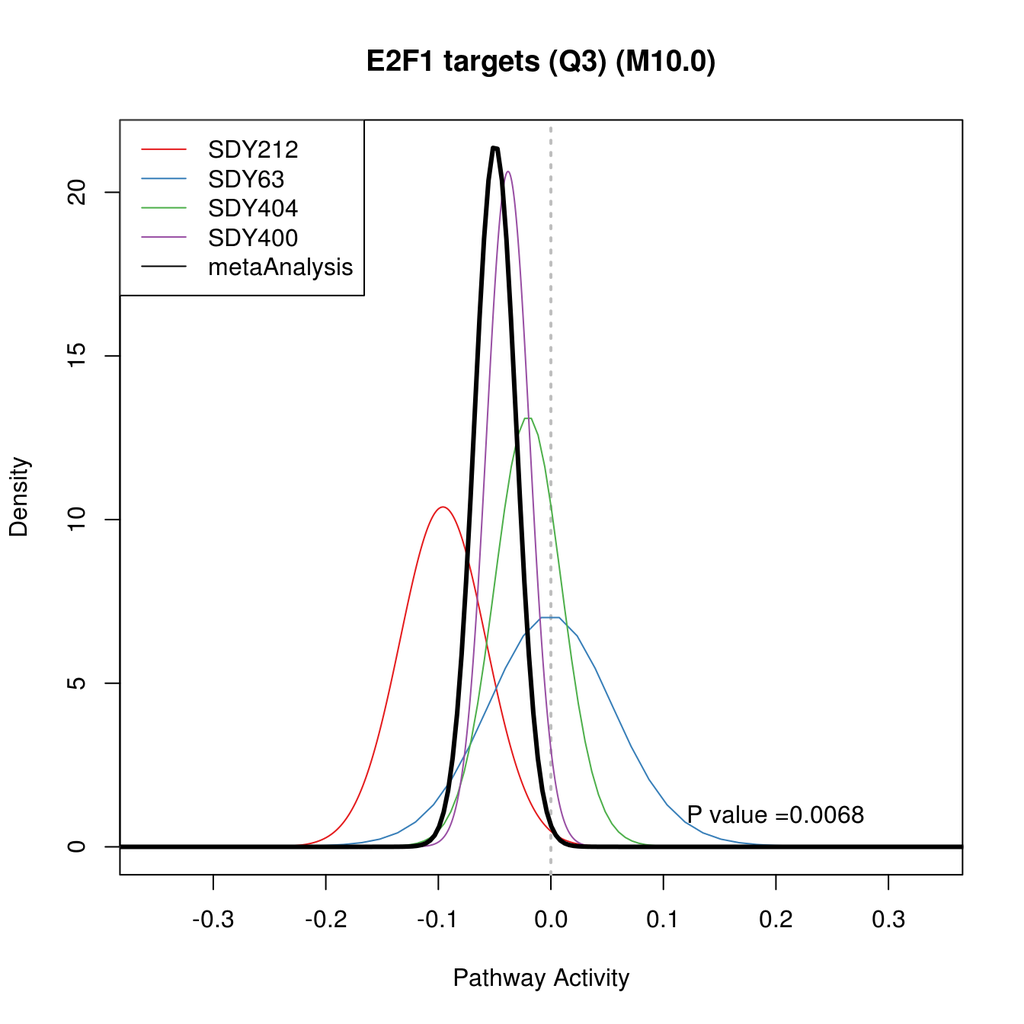

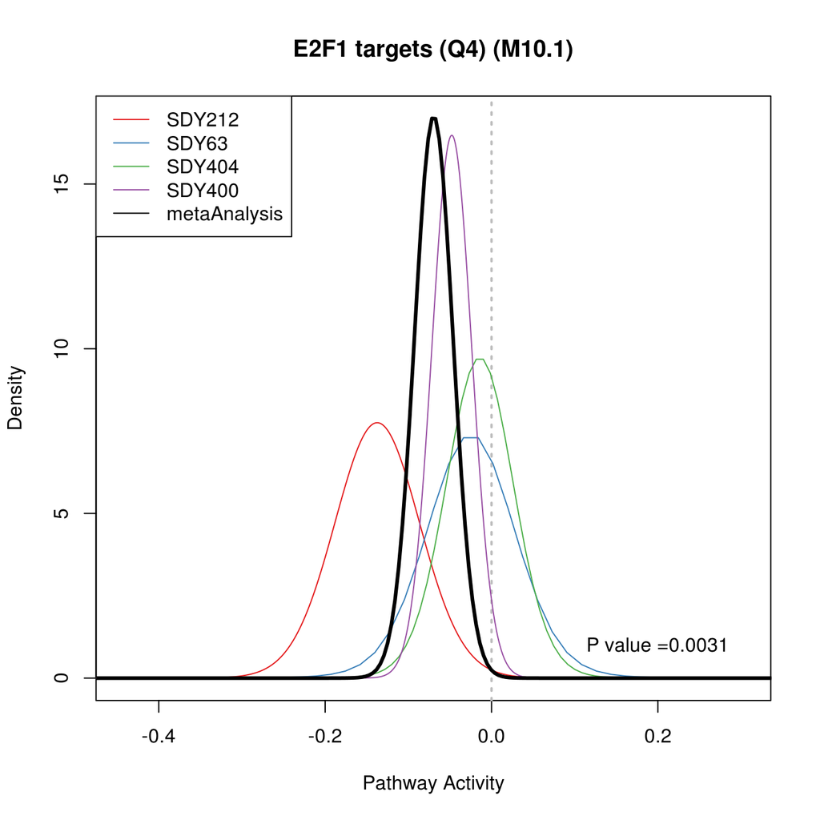

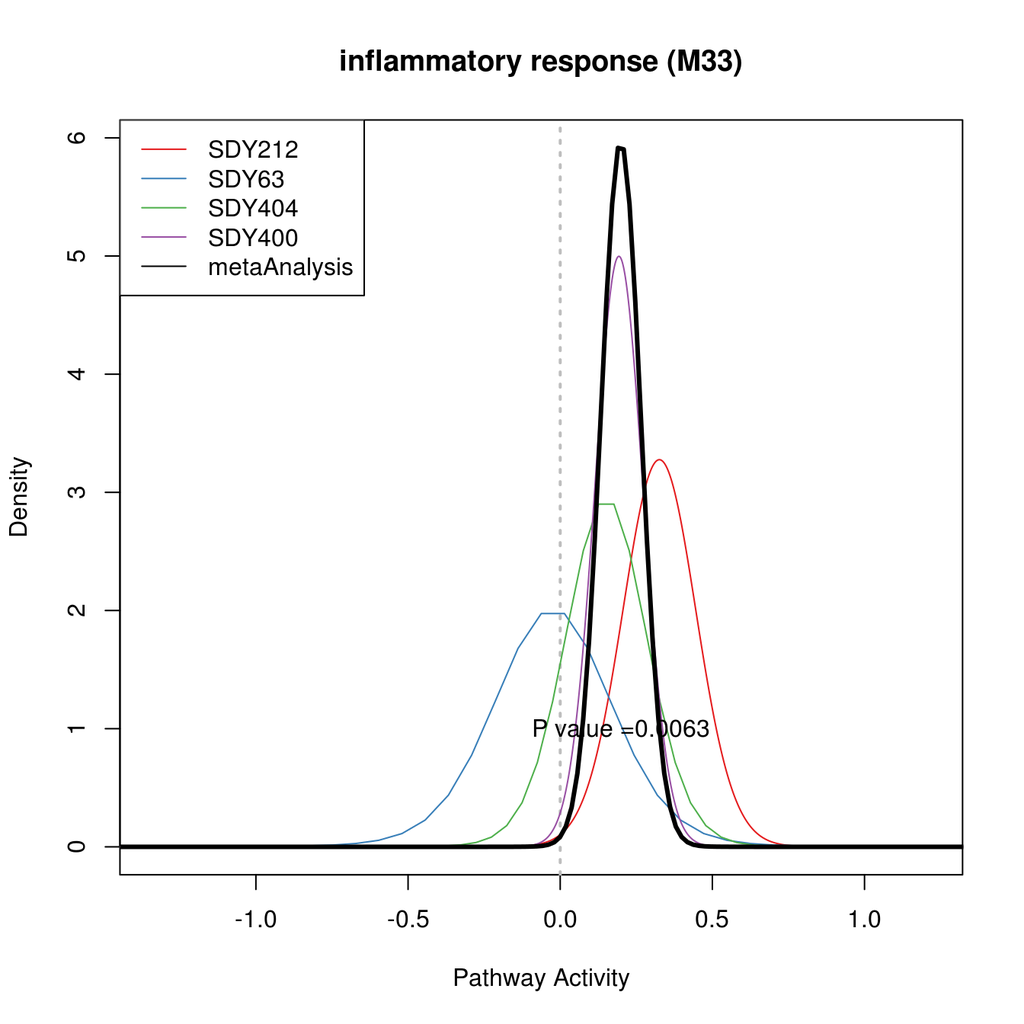

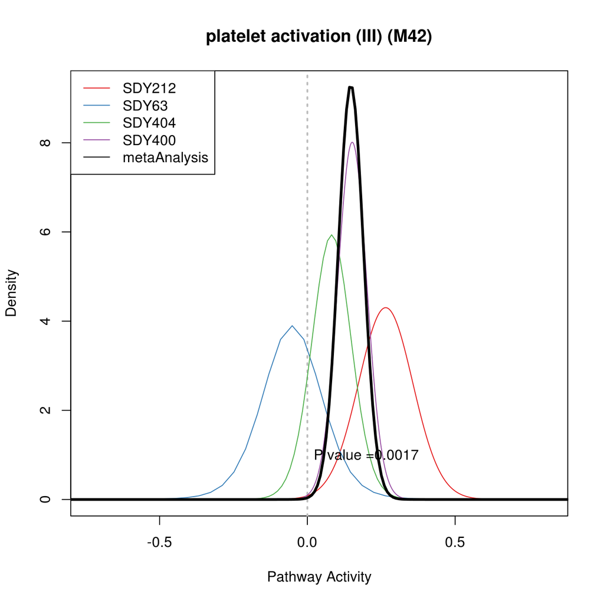

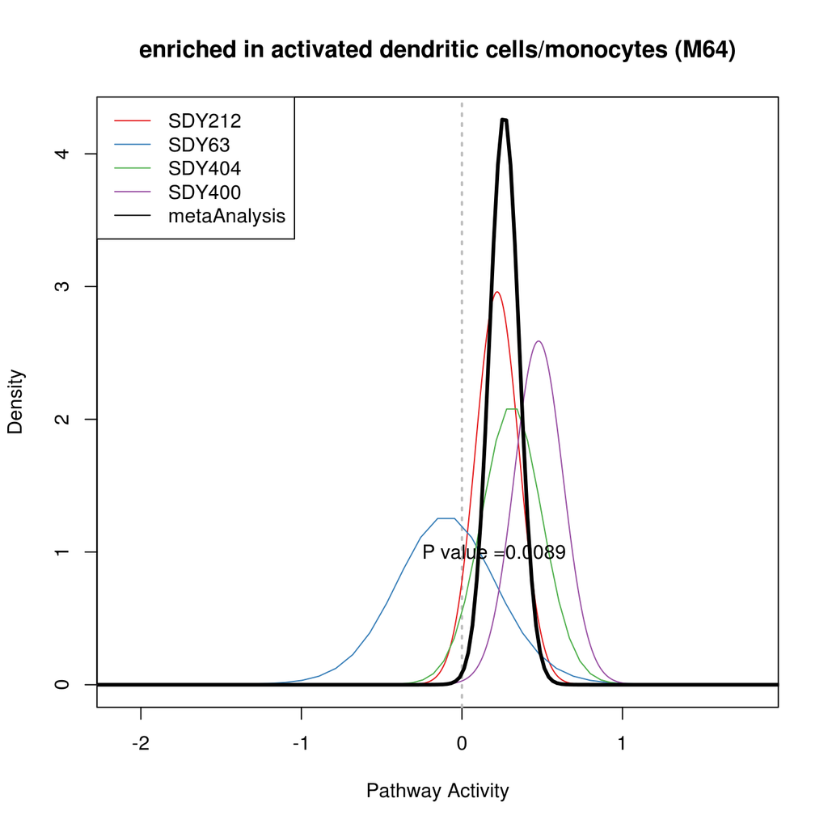

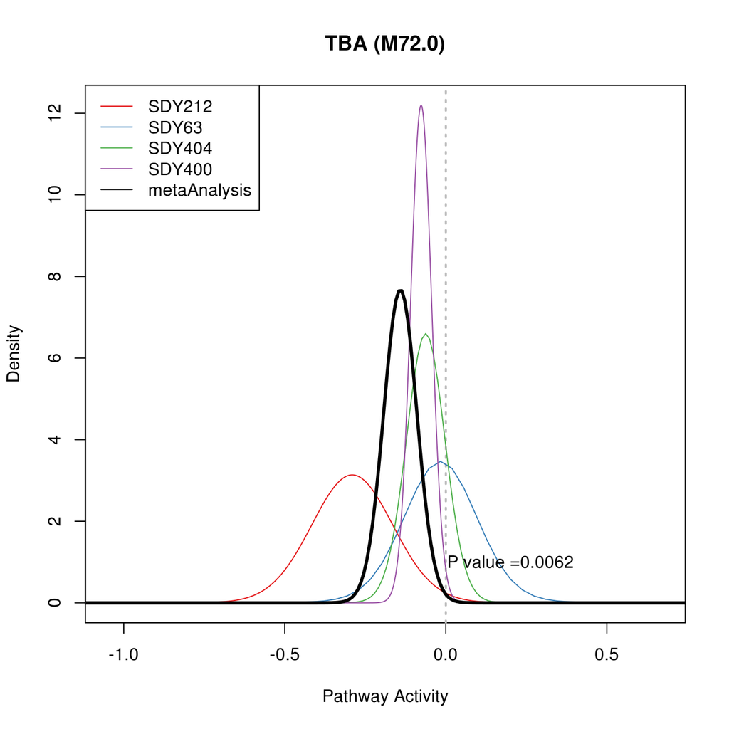

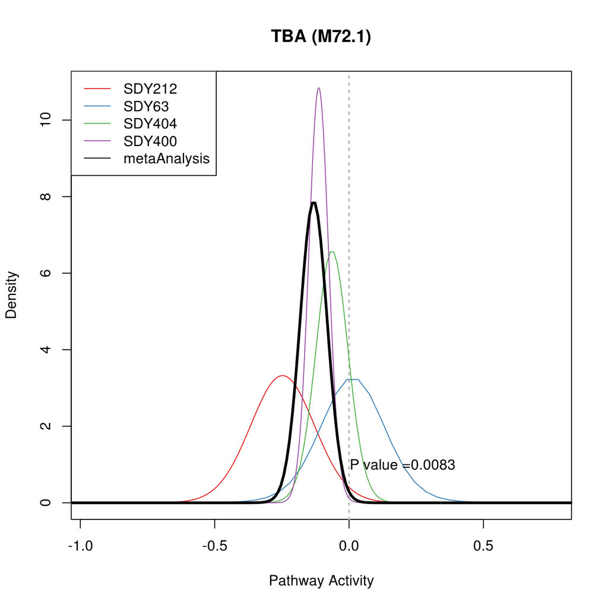

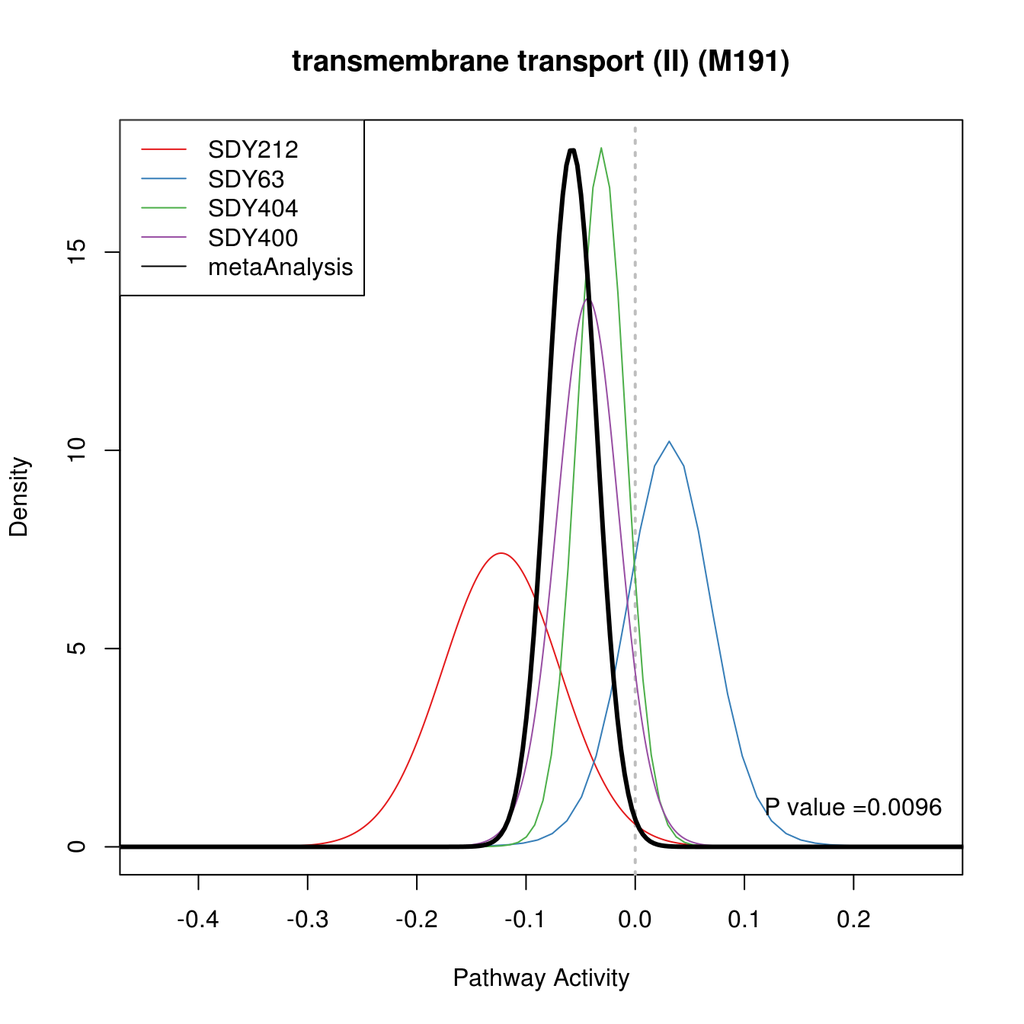

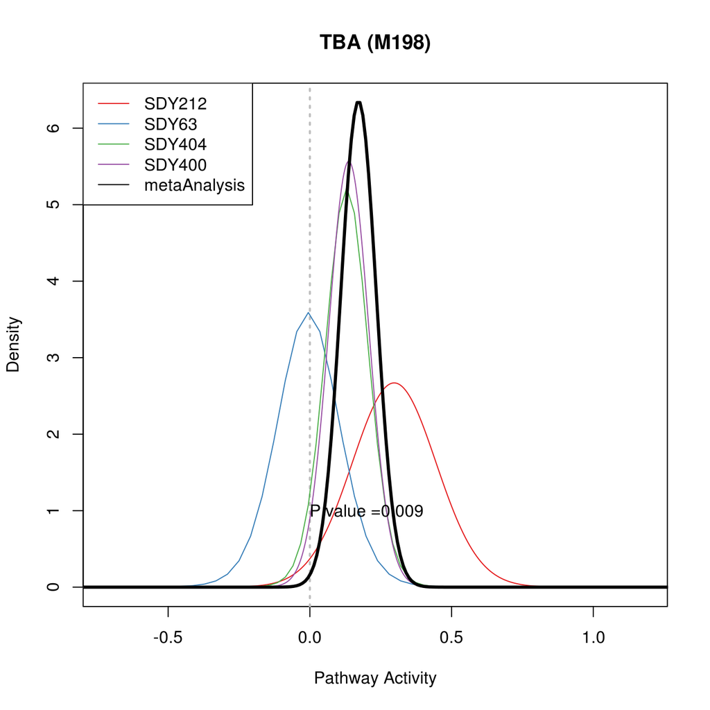

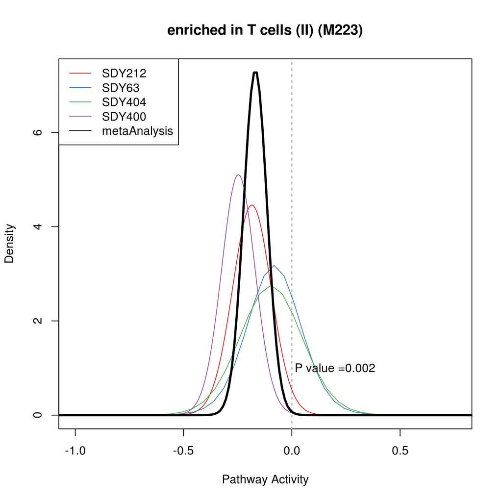

#### Discovery Group Significant Pathways Data

|  | Pvalue | FDR | pathwayActivity |
| --- | --- | --- | --- |
| targets of FOSL1/2 (M0) | 0.194297348884774 | 0.452087593753388 | 0.0623942638408579 |
| integrin cell surface interactions (I) (M1.0) | 0.908005352189114 | 0.96975966459186 | 0.00913007711685129 |
| integrin cell surface interactions (II) (M1.1) | 0.75544334135287 | 0.913927958419905 | 0.00699011353047974 |
| extracellular matrix (I) (M2.0) | 0.866505261886938 | 0.960932117348976 | 0.00480234264563726 |
| extracellular matrix (II) (M2.1) | 0.251755599876035 | 0.530741672351354 | 0.0478285980885166 |
| extracellular matrix (III) (M2.2) | 0.466364782714791 | 0.717165399196967 | -0.00707665183861004 |
| regulation of signal transduction (M3) | 0.0758220964257963 | 0.354519531936831 | 0.0948309122644514 |
| cell cycle and transcription (M4.0) | 0.464058142335065 | 0.717165399196967 | 0.0826901662463558 |
| cell cycle (I) (M4.1) | 0.50535477293295 | 0.750440993282406 | -0.0115084682843771 |
| PLK1 signaling events (M4.2) | 0.736182240503596 | 0.906473506100514 | -0.00363890164190089 |

[output cut: 336 more lines]

#### Validation Study Significant Pathways Data

|  | pvalue | qvalue | pathway.activity.selected |
| --- | --- | --- | --- |
| E2F1 targets (Q3) (M10.0) | 0.907855943213105 | 0.907855943213105 | 0.00491095430107519 |
| E2F1 targets (Q4) (M10.1) | 0.485915357719299 | 0.69110657205534 | 0.035304125 |
| inflammatory response (M33) | 0.0217602082888501 | 0.108801041444251 | 0.193218611111111 |
| platelet activation (III) (M42) | 0.00760508386002281 | 0.0760508386002281 | 0.139832625 |
| enriched in activated dendritic cells/monocytes (M64) | 0.621995914849806 | 0.69110657205534 | 0.0656799754901961 |
| TBA (M72.0) | 0.434219072294539 | 0.69110657205534 | 0.0541020833333334 |
| TBA (M72.1) | 0.218900680250073 | 0.437801360500145 | 0.0733871614583333 |
| transmembrane transport (II) (M191) | 0.0823835479862707 | 0.274611826620902 | -0.0378163425925926 |
| TBA (M198) | 0.146822255859191 | 0.367055639647979 | 0.101382666666667 |
| enriched in T cells (II) (M223) | 0.576889536723157 | 0.69110657205534 | -0.0569108333333335 |

### OLD COHORT RESULTS

```
## DISCOVERY GROUP - SIGNIFICANT PATHWAY FIGURES
```

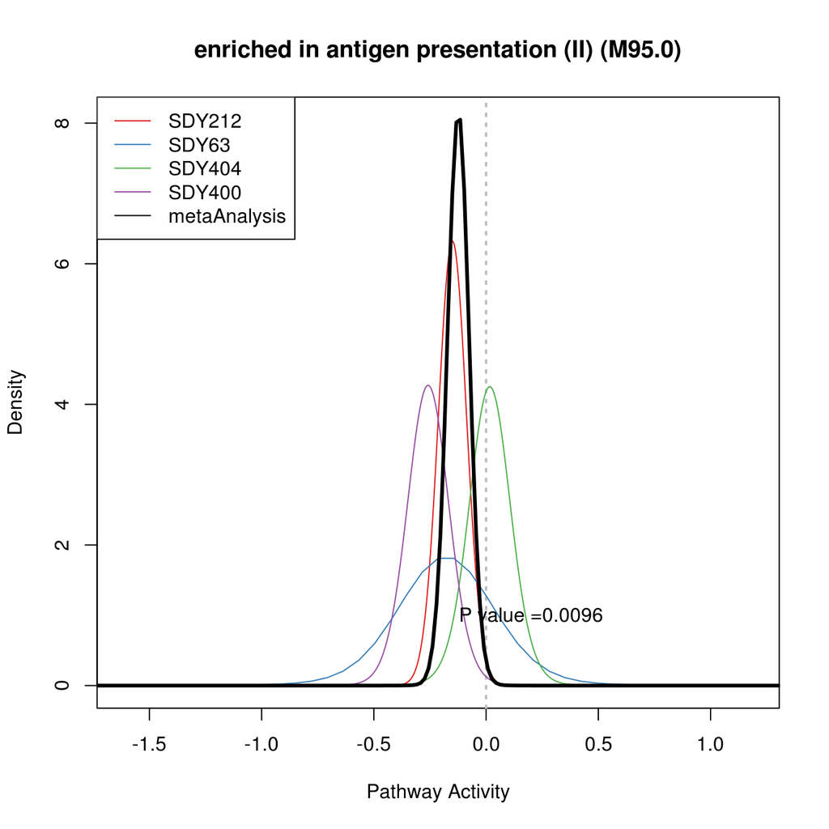

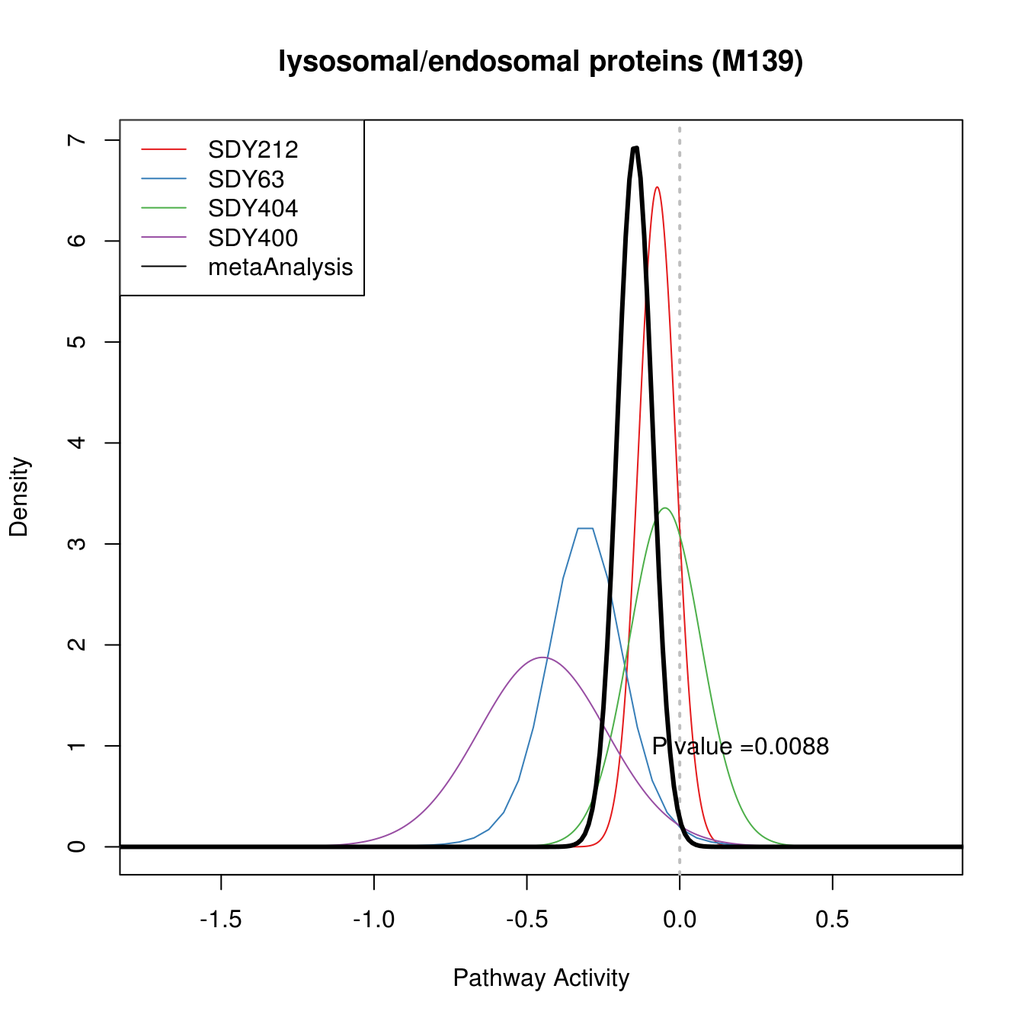

#### Discovery Group Significant Pathways Data

|  | Pvalue | FDR | pathwayActivity |
| --- | --- | --- | --- |
| targets of FOSL1/2 (M0) | 0.710232054670555 | 0.86210709723463 | 0.0168883175548934 |
| integrin cell surface interactions (I) (M1.0) | 0.393117650690017 | 0.690692728737625 | 0.0205385713435189 |
| integrin cell surface interactions (II) (M1.1) | 0.622401295437188 | 0.847837985123098 | 0.0139535703019706 |
| extracellular matrix (I) (M2.0) | 0.165749586698563 | 0.586957402000585 | -0.0146596209491002 |
| extracellular matrix (II) (M2.1) | 0.536589245750549 | 0.800258099265905 | -0.031479672411633 |
| extracellular matrix (III) (M2.2) | 0.14895349091444 | 0.586957402000585 | -0.0139574029328543 |
| regulation of signal transduction (M3) | 0.0829397190716665 | 0.53650354829081 | -0.0486665261266776 |
| cell cycle and transcription (M4.0) | 0.11766260284044 | 0.53650354829081 | -0.0420958575673367 |
| cell cycle (I) (M4.1) | 0.103924828318999 | 0.53650354829081 | 0.0204113626963176 |
| PLK1 signaling events (M4.2) | 0.174538133367176 | 0.586957402000585 | 0.0206905511991925 |

[output cut: 336 more lines]

#### Validation Study Significant Pathways Data

|  | pvalue | qvalue | pathway.activity.selected |
| --- | --- | --- | --- |
| enriched in antigen presentation (II) (M95.0) | 0.958206433841435 | 0.958206433841435 | 0.00343126587301597 |
| lysosomal/endosomal proteins (M139) | 0.95006885011898 | 0.958206433841435 | 0.00955406856060618 |

#### PARAMETERS:

- **FDR.cutoff:** 0.5
- **pvalue.cutoff:** 0.01
- **endPoint:** fc_res_max_d30
- **geneSetDB:** BTM_for_GSEA_20131008.gmt

## SINGLE GENE ANALYSIS

The single gene meta analysis was created by the Stanford HIPC collaborators and uses their package `MetaIntegrator`, which is also available on BioConductor. The plots for the Young Cohort differ here slightly from the original work by the manuscript authors because this version uses the `endPoint` column of `$young_fc_res_max_d30` which is the adjMFC for the SDY80 subjects calculated with only subjects < 36 Years Old. The original work uses the `$fc_res_max_d30` which is the adjMFC metric calculated with all subjects from the study. The key line in the code is Ln132 in `hipc_multiCohortAnalysis_script_paper.R`, which reads `GEM$class <- as.integer(as.character(GEM$pheno[[field]]))`, where the field argument is set in Ln694 `SDY80day0 <- GEM_formatter(hipc_gems_valid$SDY80, field = "fc_res_max_d30")` and should read `young_fc_res_max_d30` if not using an expressionSet that has been adjusted as this report does.

### YOUNG COHORT

#### Discovery - Upregulated Genes

|  | effectSize | effectSizeStandardError | effectSizePval | effectSizeFDR | tauSquared | numStudies | cochranesQ | heterogeneityPval | fisherStatUp | fisherPvalUp | fisherFDRUp | fisherStatDown | fisherPvalDown | fisherFDRDown |
| --- | --- | --- | --- | --- | --- | --- | --- | --- | --- | --- | --- | --- | --- | --- |
| RAB24 | 0.823955939079266 | 0.133681828776797 | 7.1127522406307e-10 | 1.32083809108512e-05 | 0 | 4 | 2.07053753344247 | 0.557896177786488 | 36.0102801554716 | 1.74842380331135e-05 | 0.0367197455748613 | 4.92233384144152 | 0.765844053661623 | 0.95406438499729 |
| GRB2 | 1.35522704112498 | 0.28891369813232 | 2.72181865956477e-06 | 0.0252720862540589 | 0.101001458381049 | 4 | 4.29435773757789 | 0.231383043524752 | 56.9039997214021 | 1.88009541612489e-09 | 3.49133718774392e-05 | 2.23301981638374 | 0.973021650317331 | 0.999968521235702 |
| DPP3 | 0.792592011907794 | 0.172343388800835 | 4.24703912675066e-06 | 0.0262891721945866 | 0 | 4 | 1.07862501949821 | 0.782236432626202 | 33.0122288069115 | 6.12765918266191e-05 | 0.0392683020464345 | 4.45368383907127 | 0.814048812345389 | 0.969659963653012 |
| ACTB | 0.773402896077803 | 0.171785381906165 | 6.72706946218731e-06 | 0.0312304199782046 | 0 | 4 | 2.63361409378885 | 0.451627013186 | 30.4094809287908 | 0.000178885584077109 | 0.0503318984289685 | 3.81607698790171 | 0.873324585800243 | 0.987020867580679 |
| MVP | 0.912560994000138 | 0.211912848050724 | 1.66005417980055e-05 | 0.0485708036255314 | 0 | 4 | 0.982317210964 | 0.805530561692646 | 28.6486702322529 | 0.000365397154957416 | 0.0579950869022156 | 1.42327044946473 | 0.993909891775669 | 0.999968521235702 |
| DPP7 | 0.58877487896249 | 0.1457703232687 | 5.36661558191481e-05 | 0.0830134140344406 | 0 | 4 | 2.30343896540706 | 0.511862412659367 | 26.5412370785893 | 0.000848137275131246 | 0.0723303415594654 | 4.22945747886406 | 0.835850211407387 | 0.977394591461685 |
| ARPC4 | 0.680246223045935 | 0.168741570191988 | 5.54715214333057e-05 | 0.0830134140344406 | 0 | 4 | 0.636128837446932 | 0.888113945098823 | 25.41978089893 | 0.00131924053594944 | 0.0854839443289617 | 3.70489386434125 | 0.88271949772553 | 0.988578463681959 |
| PLEKHB2 | 0.588544962989807 | 0.146391786930379 | 5.81138601210408e-05 | 0.0830134140344406 | 0 | 4 | 1.96938365058384 | 0.578785498054093 | 29.0203612033847 | 0.000314499697712579 | 0.0562942323404347 | 5.80335181471943 | 0.669248572974276 | 0.917936775251666 |
| ARRB1 | 0.834021876957313 | 0.209987768888952 | 7.13423565039416e-05 | 0.0946305400198711 | 0 | 4 | 2.41449356571403 | 0.490942352680922 | 24.2828324635673 | 0.00205438000398969 | 0.0978200940361247 | 1.44236775762583 | 0.993624034390079 | 0.999968521235702 |

#### Discovery - Downregulated Genes

|  | effectSize | effectSizeStandardError | effectSizePval | effectSizeFDR | tauSquared | numStudies | cochranesQ | heterogeneityPval | fisherStatUp | fisherPvalUp | fisherFDRUp | fisherStatDown | fisherPvalDown | fisherFDRDown |
| --- | --- | --- | --- | --- | --- | --- | --- | --- | --- | --- | --- | --- | --- | --- |
| PTPN22 | -0.671753727431559 | 0.152320460390777 | 1.03306402989557e-05 | 0.0383679980703215 | 0.00440643119321487 | 4 | 3.14550539755656 | 0.369730602894028 | 7.24652677524943 | 0.510283027875949 | 0.782534224008068 | 32.5845744929306 | 7.31572418531674e-05 | 0.0283027079419442 |
| PURA | -0.913069116012426 | 0.213106099741591 | 1.83088651254023e-05 | 0.0485708036255314 | 0 | 4 | 1.45192294727874 | 0.693410092981753 | 2.1620244287837 | 0.97563732912543 | 0.997683698790955 | 30.6339683630429 | 0.00016321143667303 | 0.0365161009520261 |
| SP4 | -0.87339363192965 | 0.212200819072168 | 3.85700817351964e-05 | 0.0795829353136218 | 0 | 4 | 0.220133447304637 | 0.974275437255723 | 1.56490111457386 | 0.991576898871174 | 0.999931951442013 | 32.7286609587275 | 6.89204937334123e-05 | 0.0283027079419442 |
| CASP6 | -0.688560814022581 | 0.168605909285572 | 4.42961145736627e-05 | 0.0822578847632916 | 0 | 4 | 1.12985949383335 | 0.769871208361034 | 2.55600278793966 | 0.95906824756393 | 0.994434063358611 | 25.9669540430477 | 0.00106406235963905 | 0.0708348863773665 |
| NUDCD2 | -0.928695478279361 | 0.235250496495431 | 7.89096649607438e-05 | 0.0976901652214008 | 0.0329141308346503 | 4 | 3.51436676881285 | 0.318903573856103 | 3.39451865059926 | 0.9072201065916 | 0.976144912905361 | 32.9725875957132 | 6.22926346207257e-05 | 0.0283027079419442 |
| PPIB | -1.24463372318732 | 0.316905630457412 | 8.58482155518122e-05 | 0.099637585174822 | 0 | 4 | 2.06601693299292 | 0.558818302904713 | 0.588944148266525 | 0.999752163206546 | 0.999931951442013 | 33.7753896706185 | 4.46151596348985e-05 | 0.0280985879367224 |

#### Violin Plot - SDY80

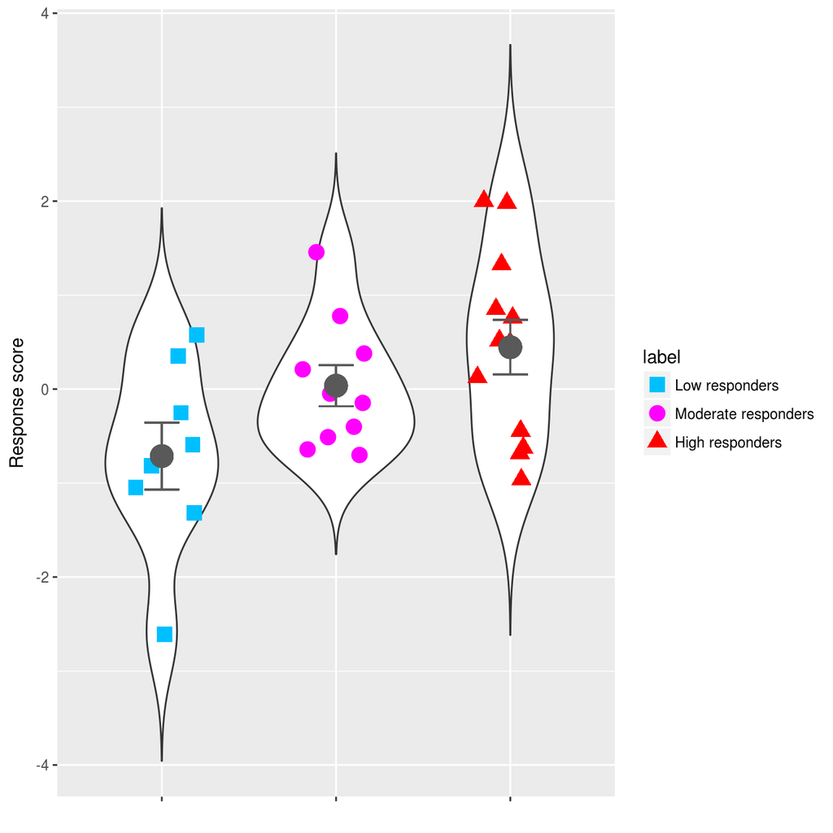

#### ROC Plot - SDY80

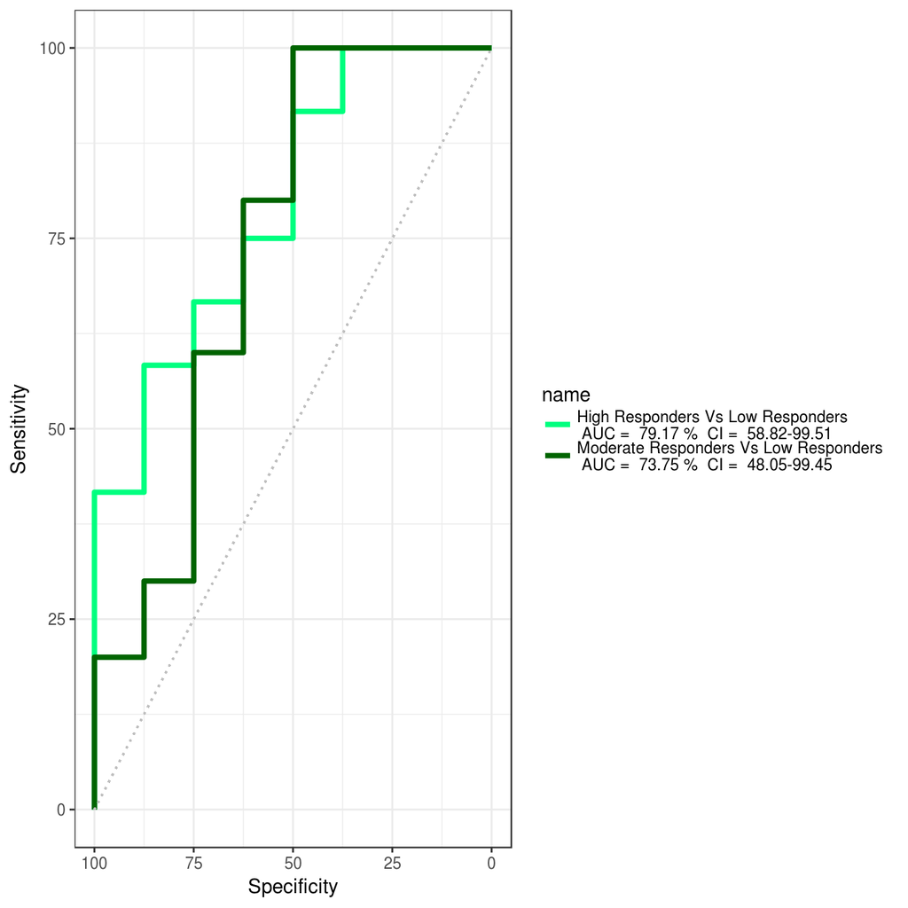

***

### OLD COHORT

No Significant up or down-regulated genes are found using the adjusted expressionSet and therefore analysis is not performed on SDY67.